# Informe

David Cruz

16/10/2020

## 1. Carga de datos y liberias.

Configuramos el directorio de trabajo y luego descargamos el conjunto de datos de su URL y descomprimimos el archivo en “activity.csv”, provenientes del enlace del curso, cargamso las librerias necesarias para el desarrollo.

```r
library(reshape2)
library(lubridate)
```

```r
library(ggplot2)
activity <- read.csv("activity.csv", sep = ",")
```

## 2.Media del número total de pasos realizados por día durante todos los días

Calculamos la media durante los dias,Agrupe el número de pasos por fecha e intervalos encontre el número total de pasos por día durante todos los días. Algunos dias no tienen datos de pasos borre esas filas para esta parte.

```r
actividades <- melt(activity[which(!is.na(activity$steps)), ], id.vars = c("date", "interval")) # Limpieza de NA
pasos <- dcast(actividades, date ~ variable, sum)
summary(pasos$steps) # Resumen
```

```
##    Min. 1st Qu.  Median    Mean 3rd Qu.    Max.
##      41    8841   10765   10766   13294   21194
```

Creamos el Histograma con el número total de pasos dados cada día, tambien se hizo el histograma con ggplot.

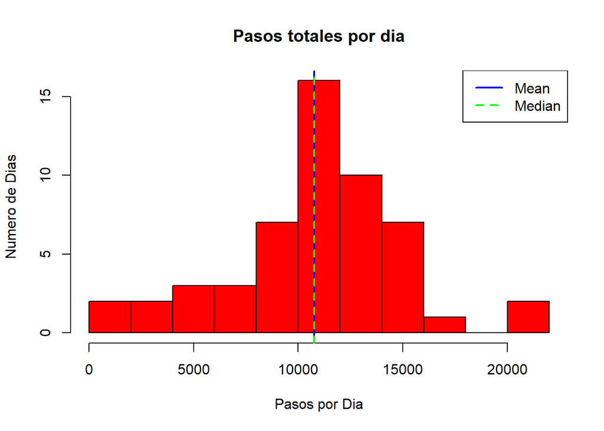

```r
hist(pasos$steps, main = "Pasos totales por dia",
     xlab = "Pasos por Dia", ylab = "Numero de Dias",
     breaks = 10, col = "Red")
abline(v = mean(pasos$steps), lty = 1, lwd = 2, col = "blue")
abline(v = median(pasos$steps), lty = 2, lwd = 2, col = "green")
legend(x = "topright", c("Mean", "Median"), col = c("blue", "green"),
       lty = c(1, 2), lwd = c(2, 2))
```

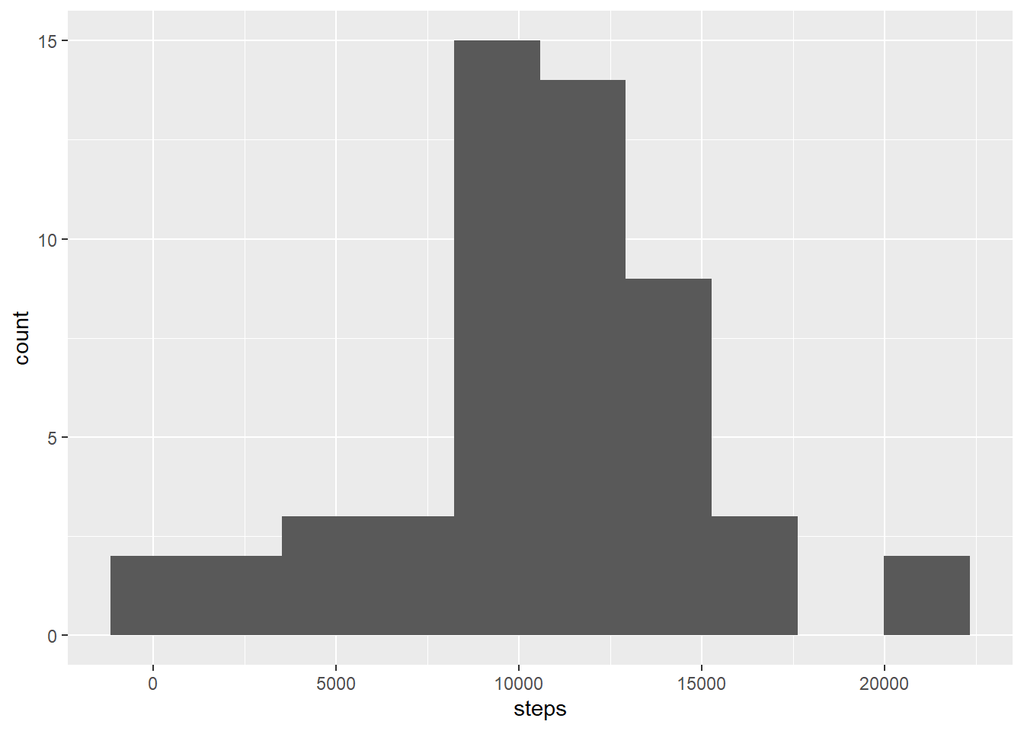

```r
ggplot(pasos, aes(steps)) + geom_histogram(bins = 10)
```

## 3.Actividad diaria promedio

En esta sección, realizamos un gráfico de series de tiempo con un intervalo de 5 minutos que se vera reflejado en el eje X y el promedio de la cantidad de pasos dados en todos los días.

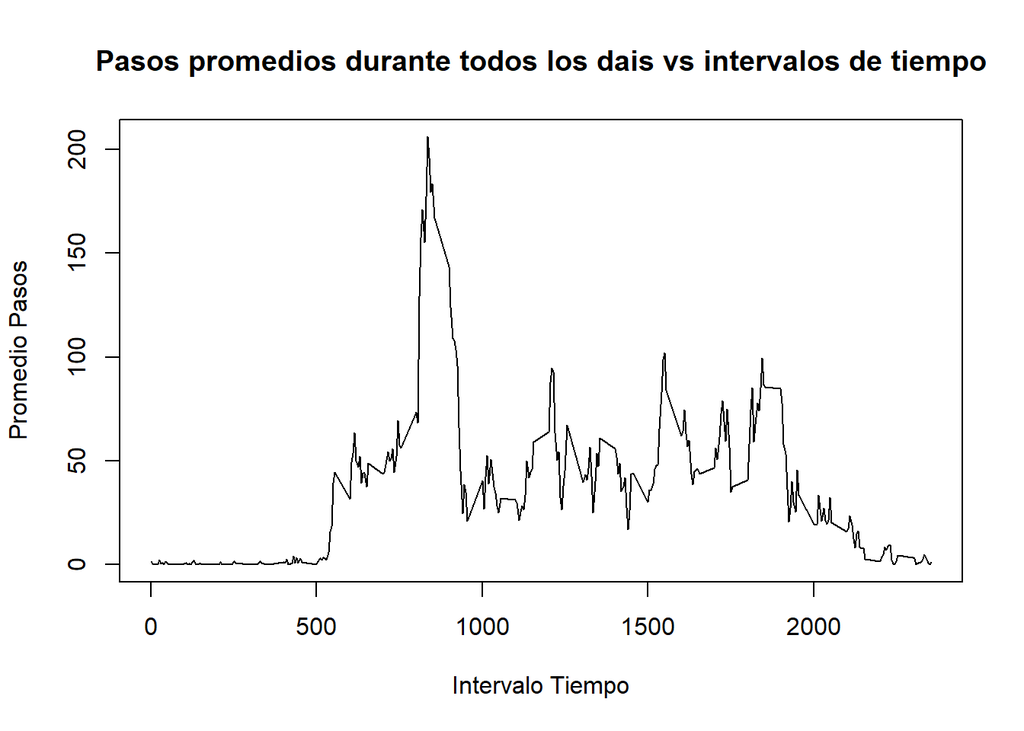

```r
pasos_intervalo <- dcast(actividades, interval ~ variable,
                           mean, na.rm = TRUE)


plot(pasos_intervalo$interval, pasos_intervalo$steps, ty = "l",
     xlab = "Intervalo Tiempo", ylab = "Promedio Pasos",
     main = "Pasos promedios durante todos los dais vs intervalos de tiempo")
```

El intervalo de tiempo durante el cual se toma el número máximo de pasos

```r
maximos_pasos <-
  pasos_intervalo$interval[which.max(pasos_intervalo$steps)]
maximos_pasos
```

```
## [1] 835
```

## 4.valores perdidos

Realizamos en primer lugar averiguar en que dias con todos los intervalos de tiempo los valores de los pasos NA, intentamos remplazar los datos faltantes de algunos dias por el promedio de tiempo de todos los demas dias.

```r
## Valores perdidos
actividad2 <- split(activity, activity$interval)
actividad2 <- lapply(actividad2, function(x) {
  x$steps[which(is.na(x$steps))] <- mean(x$steps, na.rm = TRUE)
  return(x)
})
actividad2 <- do.call("rbind", actividad2)
row.names(actividad2) <- NULL

actividad2 <- split(actividad2, actividad2$date)
a <- lapply(actividad2, function(x) {
  x$steps[which(is.na(x$steps))] <- mean(x$steps, na.rm = TRUE)
  return(x)
})
actividad2 <- do.call("rbind", actividad2)
row.names(actividad2) <- NULL
head(actividad2)
```

```
##       steps       date interval
## 1 1.7169811 2012-10-01        0
## 2 0.3396226 2012-10-01        5
## 3 0.1320755 2012-10-01       10
## 4 0.1509434 2012-10-01       15
## 5 0.0754717 2012-10-01       20
## 6 2.0943396 2012-10-01       25
```

Recalculamos

```r
pasos2 <- melt(actividad2, id.vars = c("date", "interval"))
pasos_sum <- dcast(pasos2, date ~ variable, sum, na.rm = TRUE)
head(pasos_sum)
```

```
##         date    steps
## 1 2012-10-01 10766.19
## 2 2012-10-02   126.00
## 3 2012-10-03 11352.00
## 4 2012-10-04 12116.00
## 5 2012-10-05 13294.00
## 6 2012-10-06 15420.00
```

Histograma del número total de pasos dados cada día con los valores perdidos.

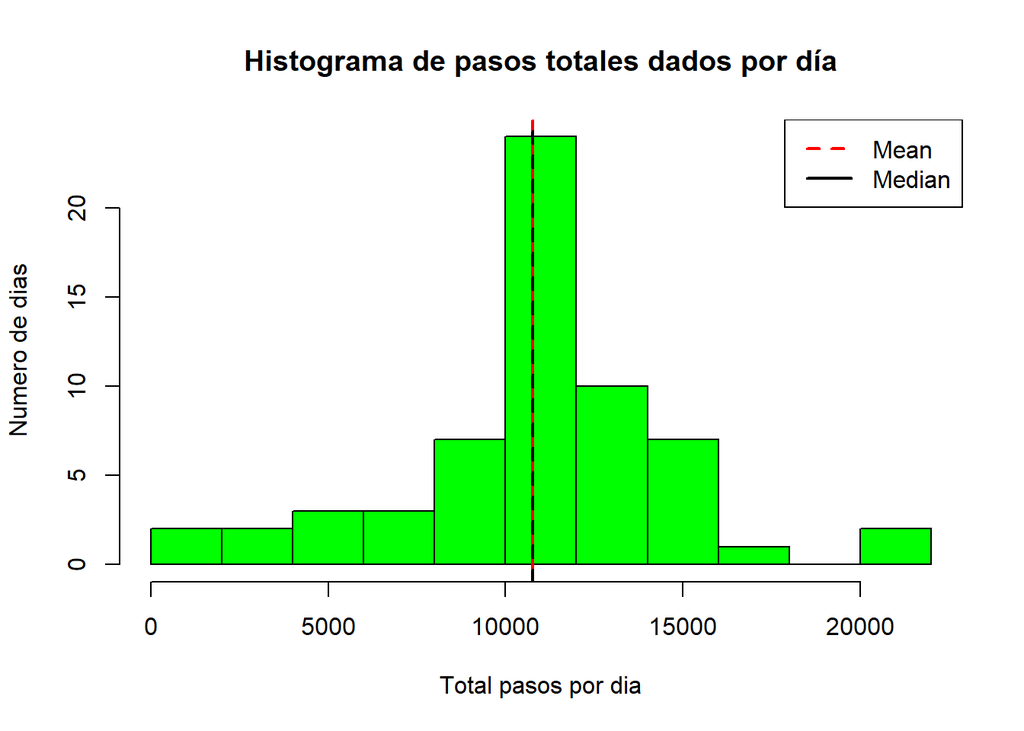

```r
hist(pasos_sum$steps, main = "Histograma de pasos totales dados por día",
     xlab = "Total pasos por dia", ylab = "Numero de dias",
     breaks = 10, col = "Green")
abline(v = mean(pasos_sum$steps), lty = 1, lwd = 2, col = "red")
abline(v = median(pasos_sum$steps), lty = 2, lwd = 2, col = "black")
legend(x = "topright", c("Mean", "Median"), col = c("red", "black"),
       lty = c(2, 1), lwd = c(2, 2))
```

Número de filas con valores NA

```r
sum(is.na(activity$steps))
```

```
## [1] 2304
```

```r
sum(is.na(activity$steps))*100/nrow(activity)
```

```
## [1] 13.11475
```

## 5. Diferencias en los patrones de actividad: días laborables frente a fines de semana

Creamos dos variable para separar dias laborales frente a los dias fines de semana.

```r
Fin_semana <- which(weekdays(as.Date(actividad2$date)) == "sábado" |
                    weekdays(as.Date(actividad2$date)) == "domingo")
entre_semana <- which(weekdays(as.Date(actividad2$date)) != "sábado" &
                    weekdays(as.Date(actividad2$date)) != "domingo")


temp <- c(rep("a", length(actividad2)))

temp[Fin_semana] <- "Fin_semana"
temp[entre_semana] <- "entre_semana"
length(temp)
```

```
## [1] 17568
```

```r
actividad2 <- cbind(actividad2, temp)
head(actividad2)
```

```
##       steps       date interval         temp
## 1 1.7169811 2012-10-01        0 entre_semana
## 2 0.3396226 2012-10-01        5 entre_semana
## 3 0.1320755 2012-10-01       10 entre_semana
## 4 0.1509434 2012-10-01       15 entre_semana
## 5 0.0754717 2012-10-01       20 entre_semana
## 6 2.0943396 2012-10-01       25 entre_semana
```

```r
names(actividad2)[4] <- "day"
```

Los pasos realizados en cada intervalo promediaron los días de la semana y los fines de semana.

```r
actividad2_split <- split(actividad2, actividad2$day)

media_pasos <- lapply(actividad2_split, function(x) {
  temp <- aggregate(x$steps, list(x$interval), mean)
  names(temp) <- c("interval", "steps")
  return(temp)
})


## Entre semana y fin de semana
media_pasos <- do.call("rbind", media_pasos)
entre_semana <- grep("entre_semana" ,row.names(media_pasos))
Fin_semana <- grep("Fin_semana" ,row.names(media_pasos))
temp <- c(rep("a", length(media_pasos$steps)))
temp[entre_semana] <- "entre_semana"
temp[Fin_semana] <- "Fin_semana"
names(temp) <- "DIA"
media_pasos <- cbind(media_pasos, temp)
row.names(media_pasos) <- NULL
head(media_pasos)
```

```
##   interval      steps         temp
## 1        0 2.25115304 entre_semana
## 2        5 0.44528302 entre_semana
## 3       10 0.17316562 entre_semana
## 4       15 0.19790356 entre_semana
## 5       20 0.09895178 entre_semana
## 6       25 1.59035639 entre_semana
```

```r
tail(media_pasos)
```

```
##     interval       steps       temp
## 571     2330  1.38797170 Fin_semana
## 572     2335 11.58726415 Fin_semana
## 573     2340  6.28773585 Fin_semana
## 574     2345  1.70518868 Fin_semana
## 575     2350  0.02830189 Fin_semana
## 576     2355  0.13443396 Fin_semana
```

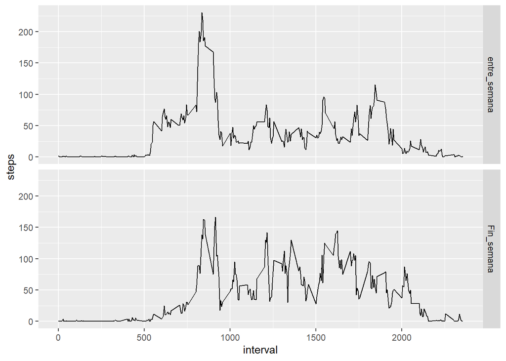

```r
names(media_pasos)[3] <- "day"
ggplot(media_pasos, aes(interval, steps)) + geom_line() + facet_grid(day ~ .)
```

El número medio de pasos realizados durante los días laborables y los fines de semana.

```r
medio_pasos <- melt(media_pasos, id.vars = c("interval",
                                                      "day"))
dcast(medio_pasos, day ~ variable, mean) # promedio
```

```
##            day    steps
## 1 entre_semana 35.61058
## 2   Fin_semana 42.36640
```